# Exercise 9: Moving towards spatial prediction

# Exploring the data

Let’s see if we can get more insights from looking at the density of the sites

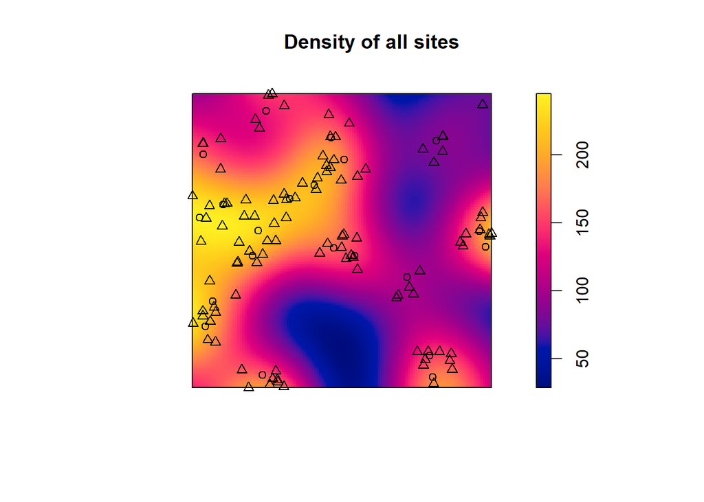

```r
# Overall density of all points in our data
dens<- density.ppp(sitesP)
# Plot interpolated values
plot(dens, main = "Density of all sites")
plot(sitesP, add = T)
```

OK, now we can see quite clearly how the patterning changes over space. Since we also have the two different site types, we can evaluate them separately.

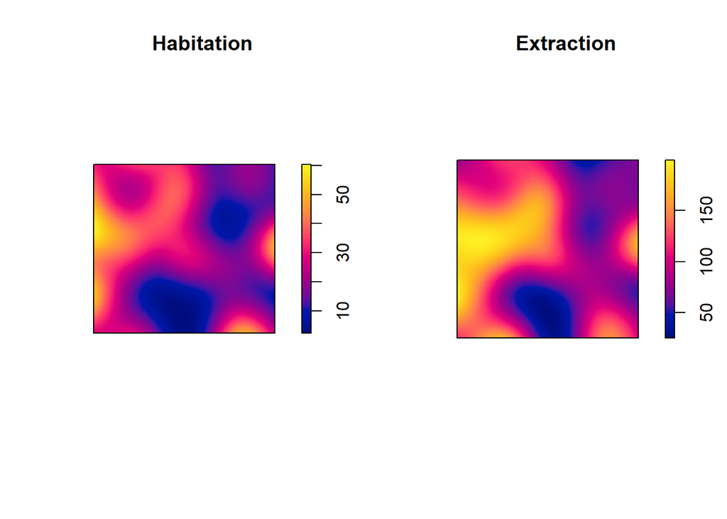

```r
par(mfrow=c(1,2)) # Set number of plotting rows to 1 and number of columns to 2

plot(density(habP), main = "Habitation")
plot(density(exP), main = "Extraction")
```

The patterns seem related, but visualizations alone can be misleading. How do we formally characterise this? First, it’s important to make note of any significant spatial relationships:

```r
clarkevans.test(habP)
```

```
##
##  Clark-Evans test
##  No edge correction
##  Z-test
##
## data:  habP
## R = 1.1641, p-value = 0.1504
## alternative hypothesis: two-sided
```

R > 1 among habitation sites indicates a more regular or dispersed pattern, but this is not significant.

```r
clarkevans.test(exP)
```

```
##
##  Clark-Evans test
##  No edge correction
##  Z-test
##
## data:  exP
## R = 0.688, p-value = 9.582e-10
## alternative hypothesis: two-sided
```

An R < 1 among extraction sites indicates potential clustering of the secondary sites, and this is significant. However, note that the feedback tells us there’s no correction. Since we don’t really know what conditions are like outside the boundary, we may want to apply an edge correction. Here we’ll use the “Donnelly” correction, one of several options. We’ll also use simulations of CSR to evaluate the test (with the `nsim` argument):

```r
#With edge correction
clarkevans.test(habP, correction = c("Donnelly"), nsim = 99)
```

```
##
##  Clark-Evans test
##  Donnelly correction
##  Monte Carlo test based on 99 simulations of CSR with fixed n
##
## data:  habP
## R = 1.053, p-value = 0.76
## alternative hypothesis: two-sided
```

```r
clarkevans.test(exP, correction = c("Donnelly"), nsim = 2000)
```

```
##
##  Clark-Evans test
##  Donnelly correction
##  Monte Carlo test based on 2000 simulations of CSR with fixed n
##
## data:  exP
## R = 0.65946, p-value = 0.0009995
## alternative hypothesis: two-sided
```

This doesn’t really change our result, although our p-values came up substantially. What this suggests is that potentially different processes are generating patterns in the habitation and extraction sites.

## Try it yourself!

The use of repeated simulationto characterize a distribution is called a Monte Carlo process. Like sample sizes, the number of simulations used will determine the precision of the estimate, but there is a tradeoff. Try changing the number of simulations used in the last two tests and running them multiple times. What happens when your number is in the single digits? What happens when its in the tens of thousands? Can you figure out what the tradeoff is?

# Evaluating the pattern

We know in this case that they are almost certainly related, but it is worthwhile to go through the process of characterizing the pattern (especially in case anything unexpected crops up!).

A good place to start is bivariate spatial statistics such as the bivariate pair-correlation function. This tests for clustering or dispersion between two point patterns, i.e. the influence of one on the other. We use the `pfcross` function to access this:

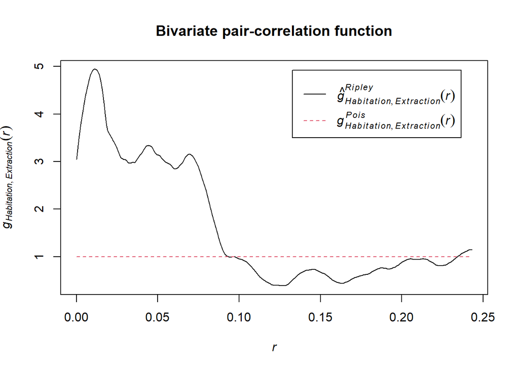

```r
plot(pcfcross(sitesP,divisor = "d", correction = "Ripley"), main = "Bivariate pair-correlation function")
```

Note the `divisor` argument here: this function can use one of two divisors, with `d` being better when many of the distance values are close to 0. In this case, since our 100 x 100 km plot is actually using unit square coordinates (e.g., 0 - 1), this is the better option.

The empirical pattern clearly differs from the same function under spatial randomness: `g(pois)`. But is this meaningful?

## Simulating to establish confidence

Like we did in Exercise 8, we can simulate envelopes of significance to compare against the empirical pattern by using the `envelope` function. This will simulate CSR many times (indicated by `nsim`) and tell us what the expected uncertainty is in this estimator.

```r
bivar <- envelope(fun = pcfcross, sitesP,
  divisor = "d",
  nsim = 39,
  correction = c("Ripley")
  )
```

```
## Generating 39 simulations of CSR  ...
## 1, 2, 3, 4, 5, 6, 7, 8, 9, 10, 11, 12, 13, 14, 15, 16, 17, 18, 19, 20, 21, 22, 23, 24, 25, 26, 27, 28, 29, 30, 31, 32, 33, 34, 35, 36, 37, 38,  39.
##
## Done.
```

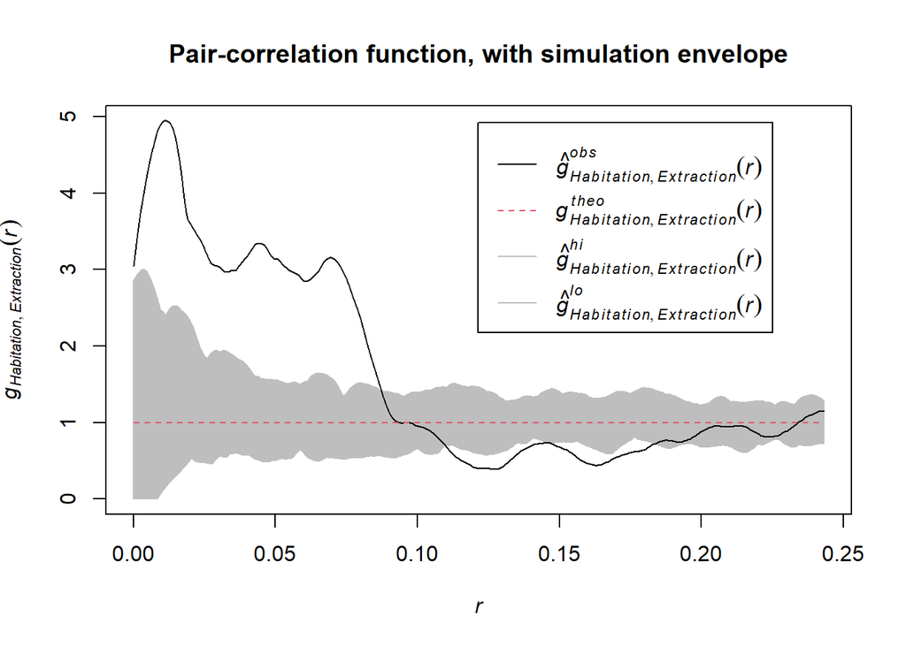

```r
plot(bivar, main = "Pair-correlation function, with simulation envelope")
```

This function shows us the following: very strong association between habtiation and extraction sites at short ranges (up to 10 km), but around 12 km and 16-17 km there are actually fewer extraction sites than expected. This is aligns well with the findings of our Clark-Evans test.

## Point process modeling

Here, we can use the kernel density of habitation sites as a way of estimating the probability of finding an extraction site. First we define an `owin` window object for the habitation sites.

```r
pwin <- as.owin(c(-0.1, 1.1, -0.1, 1.1)) #

habP$window <- pwin # Assign window
```

Next, we can run a kernel density estimate of those sites sites to act as covariate:

```r
# Kernel density estimate of primary settlement sites
pden <- density(habP)
```

Finally, we can fit a point process model to that density with `ppm`:

```r
# Fit point process model with the covariate
habFIT <- ppm(unmark(habP), ~ Cov1, covariates = list(Cov1 = pden))
```

Let’s take a look at it:

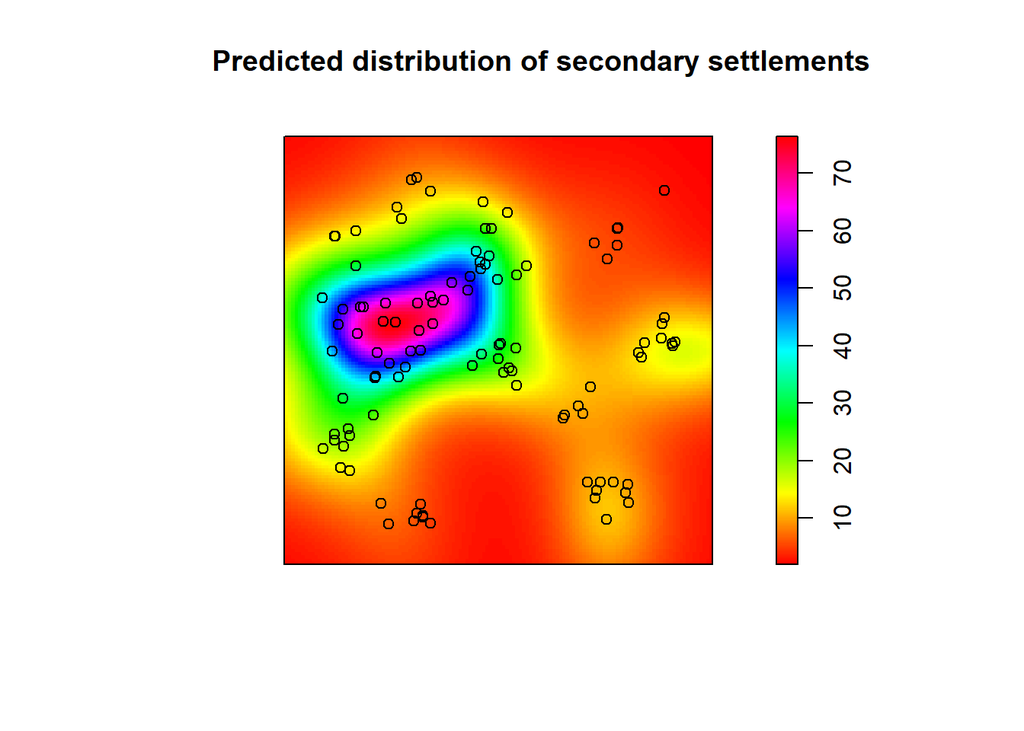

```r
plot(predict(habFIT),
     main="Predicted distribution of secondary settlements",
     col = rainbow(255))

points(exP)
```

This appears to be somewhat acceptable model; locations of extraction sites seem to be clustering on those primary sites. But how good is this fit?

# Evaluating our model

We can use the Residual K function (`Kres`)

```r
fit.res <- envelope(
  fun = Kres,
  exP,
  model = habFIT,
  nsim = 19,
  correction = c("Ripley")) # Examine
```

```
## Generating 19 simulations of CSR  ...
## 1, 2, 3, 4, 5, 6, 7, 8, 9, 10, 11, 12, 13, 14, 15, 16, 17, 18,  19.
##
## Done.
```

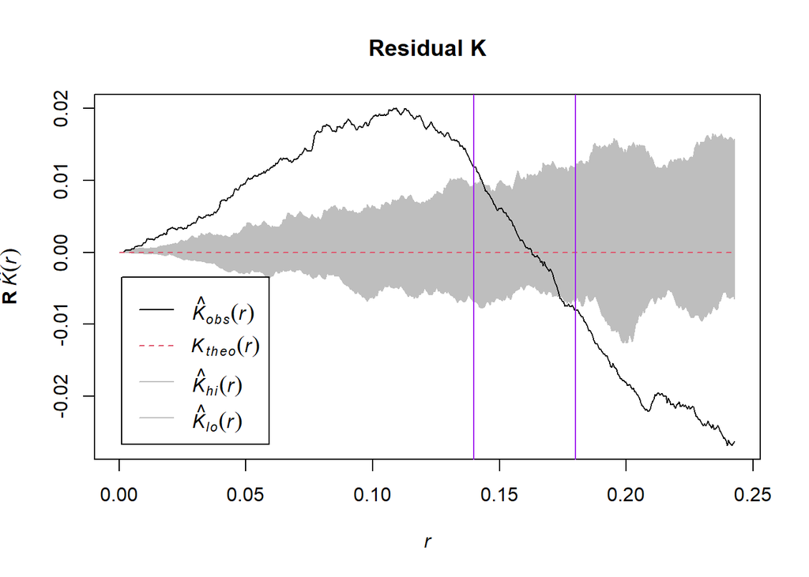

```r
plot(fit.res, main = "Residual K")

abline(v = 0.14, col = "purple")
abline(v = 0.18, col = "purple")
```

The `Kres` indicates that the locations of extraction sites, although spatially aligned with the habitation sites, are poorly explained by using only this covariate. Although a good fit is found between ~ 14 and ~18 km (the purple lines), at scales above and below this narrow band there is both significantly more dispersion and clustering, respectively. What may explain this statistical pattern?

## Try it yourself!

- A similar technique to gauge goodness of fit is the cumulative Komolgoro-Smirnov test. You can read about it with `?cdf.test`. Try running this for the extraction sites with habFIT as the covariate. (hint: you may need to use `unmark` and `predict` to make these work. )